# Man vs model: random forest tuning and optimisation

Luke Hayden

Oct 1st, 2018

# Optimising random forest

I have been working on fine-tuning the parameters of the random forest in order to improve its predictive power. In particular, I have been focused on dealing with the overfitting issue. I have been playing around with the following parameters:

ntree: number of trees

mtry: Number of variables randomly sampled as candidates at each split

min.node.size: sets depth of trees

cross-validation folds: number of repartitions of data for testing

splitting model: variance or “extratrees”

This is how they affect the model, below. Note: lower RMSE is better.

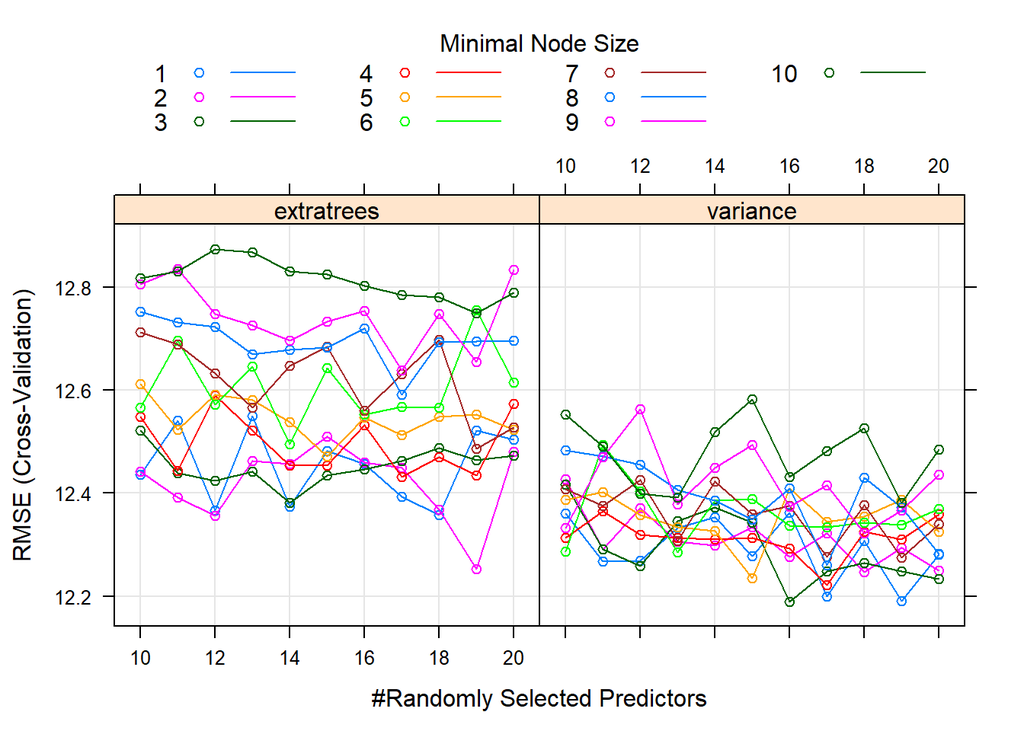

The fit is like this:

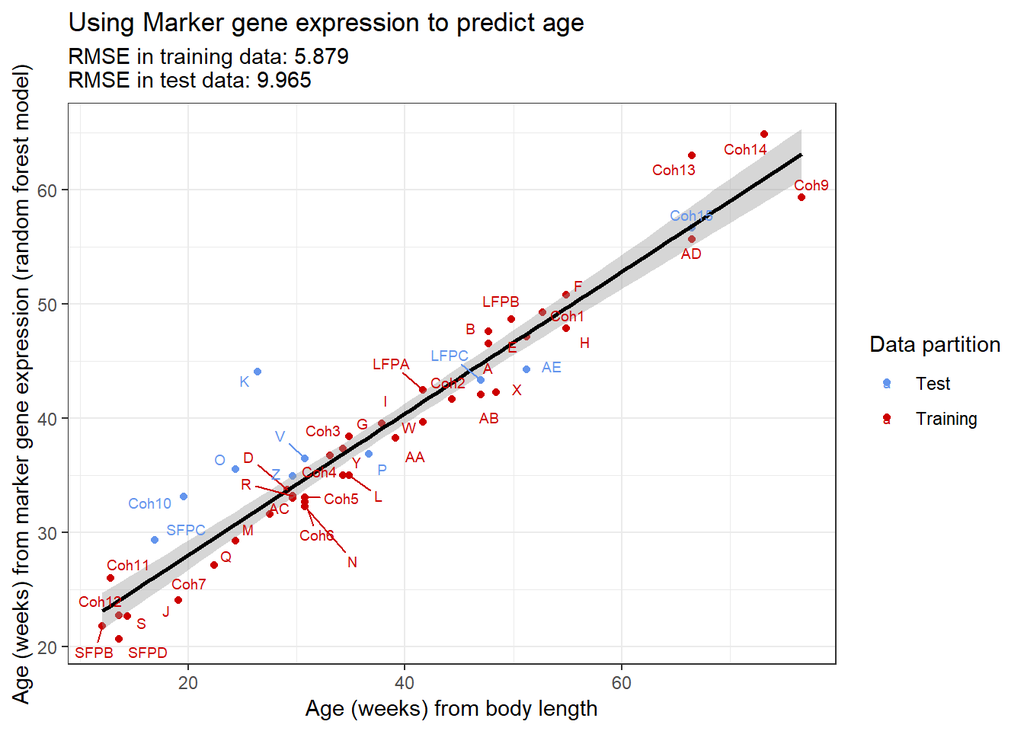

Which looks to be a pretty major improvement in terms of dealing with the overfitting. Some additional optimisation may help some more.

# Interrogating the model

Markers used:

```
##  [1] "EN015759" "BG004303" "HN023680" "FS020036" "BE003938" "FO019861"
##  [7] "GK021727" "BB003709" "BC003892" "FU020102" "HT024972" "DN012618"
## [13] "AD000121" "BF003983" "FA017924" "GQ022108" "FG018829" "HV025417"
## [19] "BR006163" "DO012850" "GO022000" "DP013027" "FD018028" "GS022306"
## [25] "AG000652" "FV020159" "FF018771" "AS001982" "AU002135" "EI015273"
## [31] "DE011835" "IH026477" "EY017812" "EF015131" "CC007861" "EH015179"
## [37] "AX003365" "IJ026696" "HA022714" "CH008359" "FI018840" "IE026183"
## [43] "AI000950" "BW007487" "CW011055" "GT022351" "DV013912" "ED014989"
## [49] "CZ011276" "FJ018935" "EB014820" "CM009084" "EC014836" "GY022551"
## [55] "IK000735"
```

#### Variable importance

Variable importance obtained via permutation

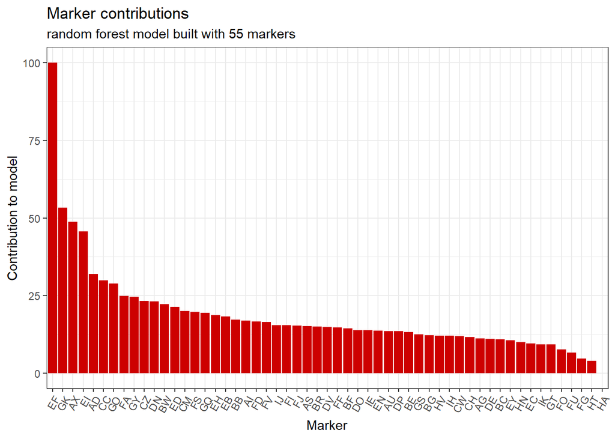

## Marker profiles

I have also graphed the expression of each marker over time.

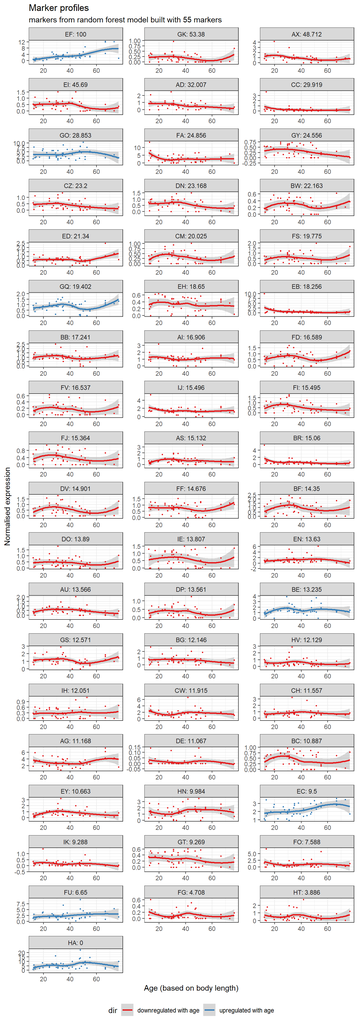

It looks like some optimisation on the basis of these profiles may furhter improve the model’s fit.